# IODS course project

Ripsa Niemi

# About the project

This is a project done in University of Helsinki in a course **Introduction to Open Data Science** during Fall 2019. Project includes different statistical methods, tests and visualizations used to different open source datasets.

During this course I became more comfortable using R and it’s packages. It became one of my favorite courses of all time! I was really excited about doing analyses with different data sets and also learning how to visualize and wrangle data better.

My GitHub repository [can be found here](https://github.com/ripsaniemi/IODS-project).

# Week 2: Linear regression

### 1)

### Exploring the datasets of the week

```r
data <- read.csv("data/learning2014.csv")

head(data)
```

```
##   gender age attitude     deep  stra     surf points
## 1      F  53       37 3.583333 3.375 2.583333     25
## 2      M  55       31 2.916667 2.750 3.166667     12
## 3      F  49       25 3.500000 3.625 2.250000     24
## 4      M  53       35 3.500000 3.125 2.250000     10
## 5      M  49       37 3.666667 3.625 2.833333     22
## 6      F  38       38 4.750000 3.625 2.416667     21
```

```r
str(data)
```

```
## 'data.frame':    166 obs. of  7 variables:
##  $ gender  : Factor w/ 2 levels "F","M": 1 2 1 2 2 1 2 1 2 1 ...
##  $ age     : int  53 55 49 53 49 38 50 37 37 42 ...
##  $ attitude: int  37 31 25 35 37 38 35 29 38 21 ...
##  $ deep    : num  3.58 2.92 3.5 3.5 3.67 ...
##  $ stra    : num  3.38 2.75 3.62 3.12 3.62 ...
##  $ surf    : num  2.58 3.17 2.25 2.25 2.83 ...
##  $ points  : int  25 12 24 10 22 21 21 31 24 26 ...
```

This data was collected from students of course Introduction to Social Statistics, fall 2014.  
Data has **166 observations and 7 variables**:

- gender (M/F),
- age,
- attitude (Global attitude toward statistics),
- deep (mean of “deep approach” questions measuring seeking meaning, relating ideas and use of evidence)
- stra (mean of “Strategic approach” questions measuring organized studying and time management)
- surf (mean of “Surface approach” questions measuring Lack of purpose, Unrelated memorising, sullabys-boudness)
- points (Exam points)

### 2)

### Summary and relationships between variables

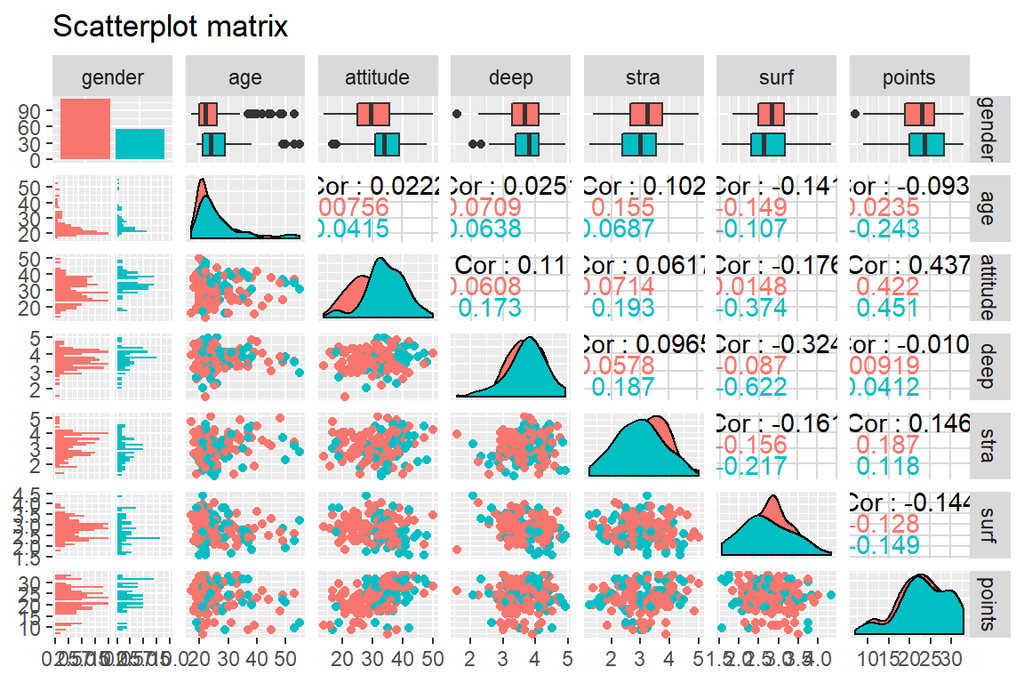

```r
library(ggplot2)
library(GGally)
g1 <- ggpairs(data, aes(color = gender)) +
  ggtitle("Scatterplot matrix")

g1
```

```r
summary(data)
```

```
##  gender       age           attitude          deep            stra
##  F:110   Min.   :17.00   Min.   :14.00   Min.   :1.583   Min.   :1.250
##  M: 56   1st Qu.:21.00   1st Qu.:26.00   1st Qu.:3.333   1st Qu.:2.625
##          Median :22.00   Median :32.00   Median :3.667   Median :3.188
##          Mean   :25.51   Mean   :31.43   Mean   :3.680   Mean   :3.121
##          3rd Qu.:27.00   3rd Qu.:37.00   3rd Qu.:4.083   3rd Qu.:3.625
##          Max.   :55.00   Max.   :50.00   Max.   :4.917   Max.   :5.000
##       surf           points
##  Min.   :1.583   Min.   : 7.00
##  1st Qu.:2.417   1st Qu.:19.00
##  Median :2.833   Median :23.00
##  Mean   :2.787   Mean   :22.72
##  3rd Qu.:3.167   3rd Qu.:27.75
##  Max.   :4.333   Max.   :33.00
```

Trough the scatter plot we can easily study how the data and variables look like. Red means female and blue male observations. Biggest difference between genders seems to be on variable attitude, where females have a clearly lower mean.

Summary function shows us that approximately 2/3 of people answering the survey are female. Mean age of pariticipants is 25.5 years old and mean points from exam was 22.7 and mean on attitude 31.4.

### 3)

### Finding explanatory variables to Points

We see that the three variables that have the highest (absolute) correlation with points are attitude, stra and surf. Lets start with a linear regression with those three as explanatory variables:

```r
r1 <- lm(points ~ attitude + stra + surf, data = data)
summary(r1)
```

```
##
## Call:
## lm(formula = points ~ attitude + stra + surf, data = data)
##
## Residuals:
##      Min       1Q   Median       3Q      Max
## -17.1550  -3.4346   0.5156   3.6401  10.8952
##
## Coefficients:
##             Estimate Std. Error t value Pr(>|t|)
## (Intercept) 11.01711    3.68375   2.991  0.00322 **
## attitude     0.33952    0.05741   5.913 1.93e-08 ***
## stra         0.85313    0.54159   1.575  0.11716
## surf        -0.58607    0.80138  -0.731  0.46563
## ---
## Signif. codes:  0 '***' 0.001 '**' 0.01 '*' 0.05 '.' 0.1 ' ' 1
##
## Residual standard error: 5.296 on 162 degrees of freedom
## Multiple R-squared:  0.2074, Adjusted R-squared:  0.1927
## F-statistic: 14.13 on 3 and 162 DF,  p-value: 3.156e-08
```

However, when we look at these three variabes only one of them, attitude, has a statistically significant p-value = 1.93e-08 (<0.05). For this reason, let’s take stra and surf out of the regression, since we can conclude that they are not making this model any better.

### 4)

### Linear regression with points as dependent variable and attitude as explanatory variable

```r
r2 <- lm(points ~ attitude, data)
summary(r2)
```

```
##
## Call:
## lm(formula = points ~ attitude, data = data)
##
## Residuals:
##      Min       1Q   Median       3Q      Max
## -16.9763  -3.2119   0.4339   4.1534  10.6645
##
## Coefficients:
##             Estimate Std. Error t value Pr(>|t|)
## (Intercept) 11.63715    1.83035   6.358 1.95e-09 ***
## attitude     0.35255    0.05674   6.214 4.12e-09 ***
## ---
## Signif. codes:  0 '***' 0.001 '**' 0.01 '*' 0.05 '.' 0.1 ' ' 1
##
## Residual standard error: 5.32 on 164 degrees of freedom
## Multiple R-squared:  0.1906, Adjusted R-squared:  0.1856
## F-statistic: 38.61 on 1 and 164 DF,  p-value: 4.119e-09
```

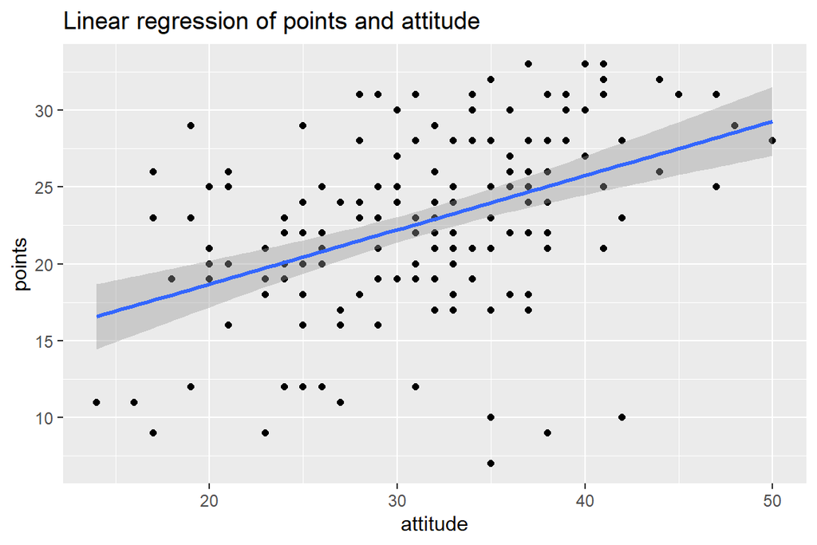

```r
g2 <- ggplot(data, aes(x = attitude, y = points)) + geom_point() + ggtitle("Linear regression of points and attitude") + geom_smooth(method = "lm")
g2
```

P-value is 4.119e-09, so this the relationship is statistically significant.

If we would want to predict values of points using variable attitude, the model would be  
y = 11.63715 + 0.35255x  
where y is points and x attitude.

This means that when attitude increases, points increases as well. This result can be seen through the scatterplot where the regression line is drawn.

R-squared is 0.19, which means that this model explains 19% of the variation of dependent variable Points.